# Newark Public School District — NJ School Data Almanac – NJ District Profiles

NJ School Data Almanac

Newark Public School District

ESSEX COUNTY · TRADITIONAL PUBLIC DISTRICT · DFG A · 43,216 STUDENTS (2026)

43,216

Students

90%

4-yr grad rate

30.3%

Gr 3-8 ELA

11.5%

Chronically absent

$21,202

Per pupil

*10 things the data says about Newark Public School District. Every figure is computed from New Jersey Department of Education data via the njschooldata package — nothing is estimated. Comparisons use District Factor Group (DFG) peers (39 districts in DFG A).*

No. 1 ACHIEVEMENT

## Newark Math Proficiency in Grades 3-8 More Than Halved During COVID, Falling to 12.7%, and Sat at 17.4% in 2024

NJSLA math proficiency for Newark’s grade 3-8 students dropped from 27.2% in 2019 to 12.7% in 2022 and had recovered to only 17.4% by 2024.

The pandemic hit math hardest in Newark’s elementary and middle schools. On the NJSLA, the state’s grades 3-8 assessment, math proficiency fell from 27.2% in 2019 to 12.7% in 2022, meaning the share of students meeting grade-level expectations was cut by more than half during the disruption.

The recovery has been slow. Math proficiency edged up to 15.1% in 2023 and 17.4% in 2024, still roughly 10 percentage points below the pre-pandemic mark. English language arts followed a milder version of the same curve, sliding from 36.0% in 2019 to 26.5% in 2022 before climbing back to 30.3% in 2024. In both subjects, the 2024 level remains under the 2019 baseline.

That fewer than one in five of Newark’s youngest tested students reaches proficiency in math, two full school years after the worst disruption, raises the stakes for the grades that feed the district’s improving high schools. At the current pace of recovery, how many more years until Newark’s grade 3-8 math proficiency returns to where it stood in 2019?

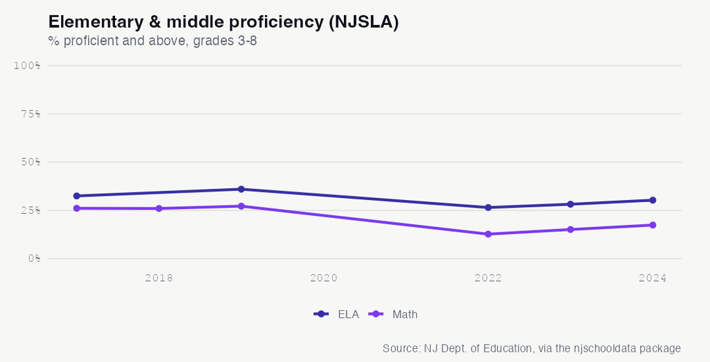

See the underlying data ›

No. 2 ATTENDANCE

## Newark’s Chronic Absenteeism Fell to 11.5%, Less Than Half the Rate Among Its Peer Districts

In 2024, 11.5% of Newark students were chronically absent, compared with a peer-group median of 24.1%.

New Jersey’s largest district has one of its lowest chronic absenteeism rates. In 2024, 11.5% of Newark Public School District students missed enough school to be flagged as chronically absent, less than half the median of 24.1% across the 39 districts in its District Factor Group A peer group.

The number is striking partly because of where Newark started. In 2019, before the pandemic disrupted school attendance everywhere, 26.8% of Newark students were chronically absent. The rate dipped to 16.6% in 2021, spiked back to 28.1% in 2022 as schools reopened, then fell sharply to 12.7% in 2023 and 11.5% in 2024.

That trajectory runs opposite to the national pattern, where chronic absence climbed and stuck after the pandemic. What did Newark change between 2022 and 2024 that cut its chronic-absence rate by more than half, and can the district hold the gain as enrollment keeps growing?

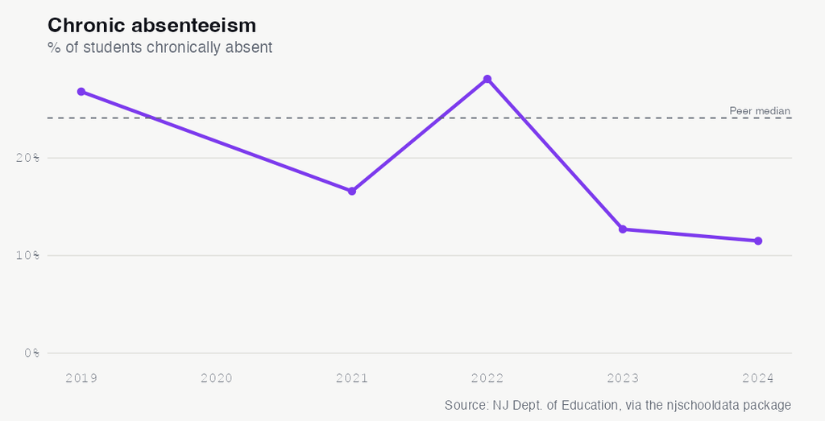

See the underlying data ›

No. 3 EQUITY

## Newark’s Former English Learners Lead All Groups in Grade 3-8 Reading at 63.9%, While Current Learners Reach 7.0%

On the 2024 NJSLA, students who had exited English-learner status outscored every racial and economic subgroup in ELA, while students still learning English trailed far behind.

The students who once needed the most language support are now Newark’s strongest readers. On the 2024 NJSLA in grades 3-8, students classified as former English learners reached 63.9% proficiency in English language arts, the highest of any group reported and more than double the district average of 30.3%.

The pattern suggests that when Newark’s language supports succeed and students reclassify, those students go on to outperform their peers, even as the district’s count of current English learners has climbed past 11,000. How quickly can Newark move its growing current-learner population toward the outcomes its former learners already achieve?

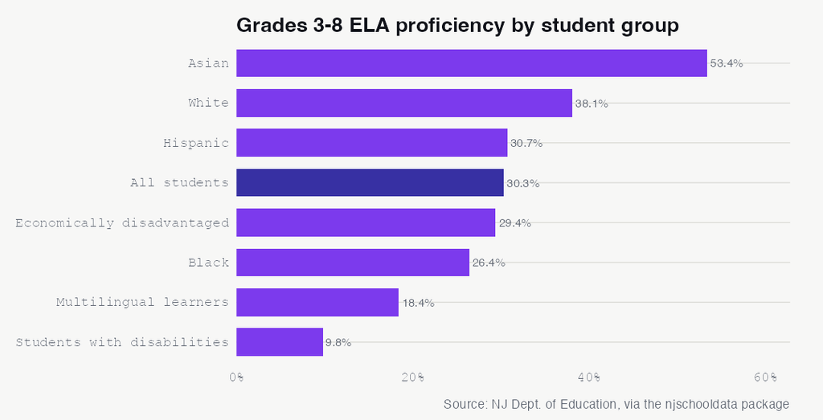

See the underlying data ›

No. 4 DEMOGRAPHICS

## Hispanic Share of Newark Enrollment Rose From 43.8% to 62.1% Since 2015 as Black Share Fell 15.8 Points

Over eleven years Newark shifted from a roughly even split between Black and Hispanic students to a clear Hispanic majority.

In 2015, Newark’s student body was nearly evenly divided: 46.8% Black and 43.8% Hispanic. By 2026, the balance had tipped decisively. Students who are Hispanic now make up 62.1% of enrollment, an increase of 18.3 percentage points, while the share of students who are Black fell 15.8 points to 31.0%.

The shift was steady rather than sudden. Hispanic share crossed 50% in 2020 and 60% by 2025. Over the same window, the share of students who are white edged down from 8.2% to 5.0%, while small groups including students who are Asian (0.7%) and students who are multiracial (0.7%) stayed in the low single digits.

This is one of the larger demographic realignments in any New Jersey district, unfolding in the state’s biggest school system. As the Hispanic majority grows, how will the district align staffing, language services, and family outreach with a student body that looks markedly different than it did a decade ago?

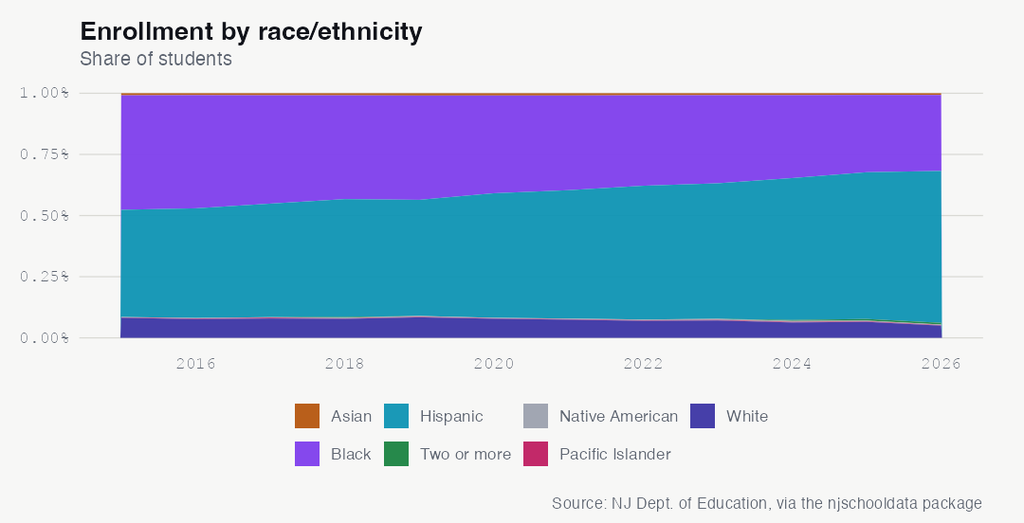

See the underlying data ›

No. 5 GRADUATION

## Newark’s Graduation Rate Hit 90% in 2025, Topping Four Out of Five Peer Districts

Newark’s four-year graduation rate reached 90.0% in 2025, an 81st-percentile result among 39 DFG A peers whose median was 85.0%.

Newark graduated 90.0% of its 2025 four-year cohort, a figure that places the district in the 81st percentile among the 39 districts in its District Factor Group A peer group, where the median rate is 85.0%.

The milestone caps a steady climb. The four-year rate sat at 80.8% in 2020 and 81.3% in 2021, then rose every year after: 85.1% in 2022, 85.7% in 2023, 86.3% in 2024, and 90.0% in 2025. The district crossed the 90% line even as the graduating cohort grew from 2,694 students in 2020 to 3,019 in 2025, meaning more students were graduating from a larger class rather than a shrinking one.

Nine-tenths of a cohort this size is roughly 2,700 diplomas in a single year. With the cohort still expanding alongside district enrollment, can Newark sustain a 90% rate as each graduating class gets larger?

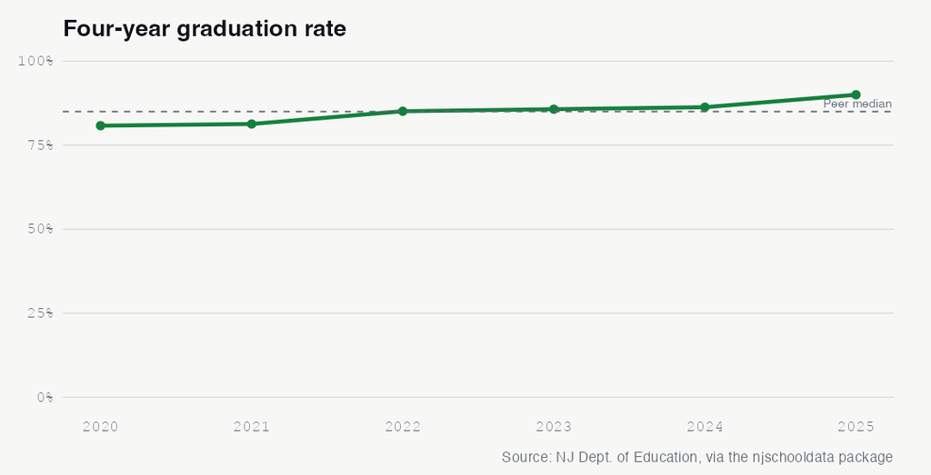

See the underlying data ›

No. 6 ENROLLMENT

## Newark Added 11,118 Students Since 2015, a 34.6% Gain That Bucks New Jersey’s Enrollment Decline

Newark grew from 32,098 students in 2015 to 43,216 in 2026, expanding through the same pandemic years when many districts shrank.

While enrollment has slid in much of New Jersey, Newark has grown. The district enrolled 32,098 students in 2015 and 43,216 in 2026, an increase of 11,118 students, or 34.6%. Enrollment peaked at 43,980 in 2025 before easing 1.7% in 2026.

The most counterintuitive stretch came during the pandemic. Between 2019 and 2022, when many districts lost students, Newark added 4,943, a 13.9% jump. Single-year gains of 9.3% in 2021 and 3.2% in 2025 drove much of the climb, with only modest dips along the way.

Growth of this scale reshapes everything from building capacity to staffing to busing. After the first enrollment decline in years in 2026, is Newark’s long expansion leveling off, or is the 764-student drop a one-year pause?

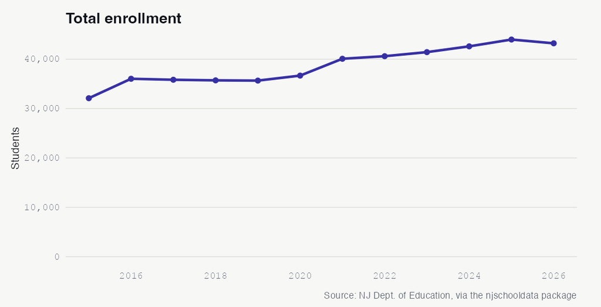

See the underlying data ›

No. 7 EQUITY

## In Newark’s 90% Graduating Class, Students With Disabilities Graduated at 76.5% and White Students at 96.7%

Newark’s 2025 graduation rate ranged from 96.7% for white students to 76.5% for students with disabilities, a 20-point span.

Behind Newark’s 90.0% overall four-year graduation rate in 2025 sits a wide range across student groups. Students who are white graduated at 96.7% and students who are multiracial at 95.2%, while students with disabilities graduated at 76.5%, a gap of more than 20 percentage points.

Most large subgroups clustered near the district average. Students who are economically disadvantaged graduated at 90.8%, students who are Hispanic at 90.5%, and multilingual learners at 89.7%. Students who are Black graduated at 88.5%, and students who are male at 87.1%, both below the 90.0% total. Students who are Asian, a small group of 31, graduated at 83.9%.

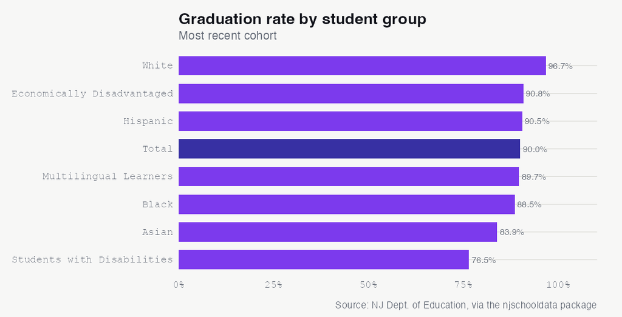

See the underlying data ›

No. 8 DEMOGRAPHICS

## Newark’s Multilingual Learners More Than Tripled to 11,884, Now 27.5% of Students

The share of Newark students classified as English learners rose from 10.9% in 2015 to 27.5% in 2026.

More than one in four Newark students is now learning English. The count of students classified as limited English proficient climbed from 3,513 in 2015 to 11,884 in 2026, more than tripling, and their share of enrollment rose from 10.9% to 27.5%.

The acceleration is recent. The share held near 11-13% through 2019, then jumped to 16.8% in 2020 and kept rising, reaching 22.1% in 2023 and 28.7% in 2025 before settling at 27.5%. The growth tracks the district’s expanding Hispanic majority, which reached 62.1% in 2026. Over the same period, the share of students who are economically disadvantaged, measured by free or reduced-price lunch eligibility, stayed high, at 77.5% in 2026.

See the underlying data ›

No. 9 FINANCE

## Newark Spent $21,202 Per Pupil in 2024, Up 22.6% Over a Decade and Above Most DFG A Peers

Per-pupil spending rose from $17,296 in 2014 to $21,202 in 2024, a 78th-percentile figure among peer districts whose median was $19,338.

Newark spent $21,202 per pupil in 2024, a 22.6% increase from $17,296 in 2014 and enough to place the district in the 78th percentile of its District Factor Group A peers, whose median is $19,338.

The path was not a straight climb. Per-pupil spending actually dipped to $16,336 by 2017 before rising steadily, crossing $18,000 in 2020 and $20,000 in 2023. Of every dollar spent in 2025, 53.8% went to classroom instruction, with 18.5% on support services and 17.8% on plant operations, while administration accounted for 8.0%.

Newark’s average daily enrollment reached 39,260 in 2024, the largest in the data and a major driver of total cost. With spending above the peer median and rising, how is the district balancing classroom investment against the operations and support costs of running New Jersey’s biggest school system?

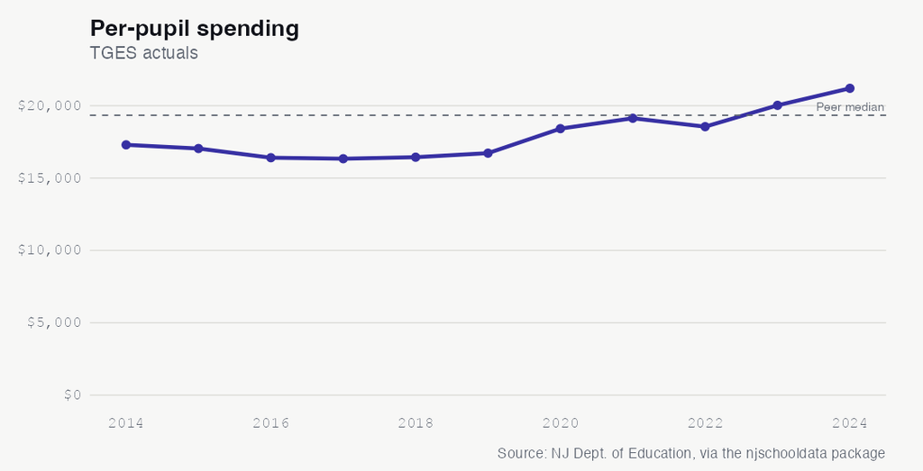

See the underlying data ›

No. 10 COLLEGE READINESS

The share of Newark students earning college credit through dual enrollment went from 0% in 2022 to 7.2% in 2024, while AP/IB success rose to 16.7%.

Newark opened a college-credit pathway almost overnight. The share of students participating in dual enrollment, in which high schoolers earn college credit, went from 0% as recently as 2022 to 0.3% in 2023 and then 7.2% in 2024, a standing start to a meaningful share in a single year.

The district’s advanced coursework expanded alongside it. In 2024, 16.7% of students scored 3 or higher on an AP exam or 4 or higher on an IB exam, up from 11.5% in 2023, while AP/IB coursework participation climbed to 28.7% from 22.9% the year before. The AP/IB exam-taking rate reached 28% in 2024.

A jump from zero to 7.2% dual enrollment in two years signals a deliberate push to put college credit within reach before graduation. Can Newark sustain that expansion, and will the students taking on dual-enrollment courses carry the credits into college completion?

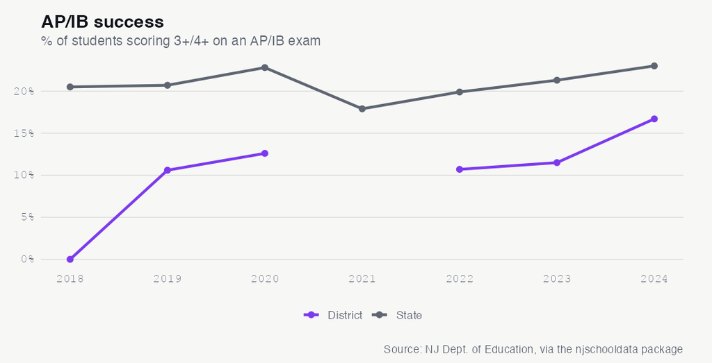

See the underlying data ›

## The Almanac

The full longitudinal record behind the stories above. Every number a reader can check.

### Enrollment (total)

| year | students | yoy | yoy_pct |
| --- | --- | --- | --- |
| 2015 | 32098 | NA | NA |
| 2016 | 36034 | 3936 | 12.3 |
| 2017 | 35836 | -198 | -0.5 |
| 2018 | 35714 | -122 | -0.3 |
| 2019 | 35664 | -50 | -0.1 |
| 2020 | 36676 | 1012 | 2.8 |
| 2021 | 40085 | 3409 | 9.3 |
| 2022 | 40607 | 522 | 1.3 |
| 2023 | 41430 | 823 | 2 |
| 2024 | 42600 | 1170 | 2.8 |
| 2025 | 43980 | 1380 | 3.2 |
| 2026 | 43216 | -764 | -1.7 |

### Demographic share (%) by year

| end_year | white | black | hispanic | asian | native_american | pacific_islander | multiracial |
| --- | --- | --- | --- | --- | --- | --- | --- |
| 2015 | 8.2 | 46.8 | 43.8 | 0.8 | 0.2 | 0.2 | 0 |
| 2016 | 7.7 | 46.3 | 44.8 | 0.8 | 0.2 | 0.3 | 0 |
| 2017 | 7.9 | 44.3 | 46.4 | 0.8 | 0.2 | 0.4 | 0 |
| 2018 | 7.8 | 42.4 | 48.2 | 0.8 | 0.2 | 0.2 | 0.3 |
| 2019 | 8.4 | 42.6 | 47.5 | 0.9 | 0.3 | 0.2 | 0 |
| 2020 | 7.8 | 40 | 50.9 | 0.9 | 0.2 | 0.2 | 0 |
| 2021 | 7.4 | 38.7 | 52.5 | 0.9 | 0.3 | 0.2 | 0 |
| 2022 | 7 | 37 | 54.7 | 0.8 | 0.3 | 0.2 | 0 |
| 2023 | 7.1 | 36 | 55.4 | 0.8 | 0.4 | 0.2 | 0 |
| 2024 | 6.3 | 33.9 | 58 | 0.8 | 0.4 | 0.2 | 0.4 |
| 2025 | 6.5 | 31.6 | 60 | 0.7 | 0.3 | 0.2 | 0.7 |
| 2026 | 5 | 31 | 62.1 | 0.7 | 0.3 | 0.2 | 0.7 |

### Special populations (LEP, FRL)

| end_year | subgroup | students | pct |
| --- | --- | --- | --- |
| 2015 | lep | 3513 | 10.9 |
| 2015 | free_reduced_lunch | 26032 | 81.1 |
| 2016 | lep | 3730 | 10.3 |
| 2016 | free_reduced_lunch | 28312 | 78.6 |
| 2017 | lep | 4221 | 11.8 |
| 2017 | free_reduced_lunch | 28466 | 79.4 |
| 2018 | lep | 4592 | 12.9 |
| 2018 | free_reduced_lunch | 30241 | 84.7 |
| 2019 | lep | 4443 | 12.5 |
| 2019 | free_reduced_lunch | 26214 | 73.5 |
| 2020 | lep | 6162 | 16.8 |
| 2020 | free_reduced_lunch | 30404 | 82.9 |
| 2021 | lep | 6414 | 16.0 |
| 2021 | free_reduced_lunch | 28621 | 71.4 |
| 2022 | lep | 6984 | 17.2 |
| 2022 | free_reduced_lunch | 30861 | 76.0 |
| 2023 | lep | 9156 | 22.1 |
| 2023 | free_reduced_lunch | 31031 | 74.9 |
| 2024 | lep | 10267 | 24.1 |
| 2024 | free_reduced_lunch | 30416 | 71.4 |
| 2025 | lep | 12622 | 28.7 |
| 2025 | free_reduced_lunch | 32721 | 74.4 |
| 2026 | lep | 11884 | 27.5 |
| 2026 | free_reduced_lunch | 33492 | 77.5 |

### Graduation rate 4yr (total)

| year | grad_rate | cohort |
| --- | --- | --- |
| 2020 | 80.8 | 2694 |
| 2021 | 81.3 | 2499 |
| 2022 | 85.1 | 2538 |
| 2023 | 85.7 | 2653 |
| 2024 | 86.3 | 2764 |
| 2025 | 90 | 3019 |

### Graduation by subgroup (2025)

| subgroup | grad_rate | cohort |
| --- | --- | --- |
| white | 96.7 | 152 |
| multiracial | 95.2 | NA |
| female | 93.2 | 1428 |
| economically disadvantaged | 90.8 | 2601 |
| hispanic | 90.5 | 1620 |
| total | 90.0 | 3019 |
| multilingual learners | 89.7 | 819 |
| black | 88.5 | 1187 |
| male | 87.1 | 1591 |
| students in foster care | 85.7 | 14 |
| students experiencing homelessness | 84.5 | 84 |
| asian | 83.9 | 31 |
| students with disabilities | 76.5 | 472 |
| american indian | NA | NA |
| migrant students | NA | NA |
| military-connected students | NA | NA |
| non-binary/undesignated gender | NA | NA |

### NJGPA high-school proficiency (% proficient+)

| year | test | prof_above | valid |
| --- | --- | --- | --- |
| 2023 | ela | 66.1 | 2178 |
| 2023 | math | 31.4 | 2201 |
| 2024 | ela | 67.0 | 2623 |
| 2024 | math | 31.2 | 2788 |
| 2025 | ela | 65.6 | 2746 |
| 2025 | math | 36.5 | 2920 |

### NJGPA ELA by subgroup (2025)

[output not shown]

### NJSLA grades 3-8 proficiency (% proficient+, enrollment-weighted across grades)

| testing_year | test_name | prof |
| --- | --- | --- |
| 2017 | ela | 32.5 |
| 2017 | math | 26.1 |
| 2018 | math | 26.0 |
| 2019 | ela | 36.0 |
| 2019 | math | 27.2 |
| 2022 | ela | 26.5 |
| 2022 | math | 12.7 |
| 2023 | ela | 28.2 |
| 2023 | math | 15.1 |
| 2024 | ela | 30.3 |
| 2024 | math | 17.4 |

### NJSLA ELA proficiency by subgroup (2024, grades 3-8)

| subgroup | prof |
| --- | --- |
| lep_former | 63.9 |
| FORMER - ML | 63.6 |
| asian | 53.4 |
| white | 38.1 |
| non_ed | 36.0 |
| other | 35.5 |
| female | 33.5 |
| hispanic | 30.7 |
| total_population | 30.3 |
| pacific_islander | 30.0 |
| ed | 29.4 |
| black | 26.4 |
| male | 26.0 |
| lep_current_former | 23.5 |
| MULTILINGUAL LEARNERS | 18.4 |
| sped_accomodations | 11.3 |
| special_education | 9.8 |
| CURRENT - ML | 8.1 |
| lep_current | 7.0 |
| american_indian | NA |

### Chronic absenteeism (% chronically absent)

| year | chronic_pct |
| --- | --- |
| 2019 | 26.8 |
| 2021 | 16.6 |
| 2022 | 28.1 |
| 2023 | 12.7 |
| 2024 | 11.5 |

### Disciplinary removals

[output not shown]

### Police notifications (incident counts)

| year | violence | weapons | vandalism | substances | hib | other |
| --- | --- | --- | --- | --- | --- | --- |
| 2019 | 34 | 6 | 4 | 14 | 2 | 1 |
| 2020 | 12 | 1 | 3 | 0 | 6 | 1 |
| 2021 | 0 | 2 | 0 | 0 | 0 | 0 |
| 2022 | 22 | 5 | 2 | 2 | 20 | 0 |
| 2023 | 7 | 2 | 3 | 0 | 11 | 0 |
| 2024 | 9 | 0 | 0 | 0 | 13 | 0 |

### HIB (harassment/intimidation/bullying) investigations

| end_year | alleged | confirmed |
| --- | --- | --- |
| 2019 | 141 | 388 |
| 2020 | 97 | 210 |
| 2021 | 12 | 9 |
| 2022 | 164 | 273 |
| 2023 | 160 | 214 |
| 2024 | 120 | 240 |

### SAT participation (% of grade)

| year | sat_part | state_sat |
| --- | --- | --- |
| 2018 | 59.4 | 72.2 |
| 2019 | 100 | 72.1 |
| 2020 | 100 | 71.1 |
| 2021 | 98.3 | 45.4 |
| 2022 | 93.1 | 60.8 |
| 2023 | 100 | 61.9 |
| 2024 | 100 | 62.7 |

### AP/IB & dual enrollment (% of students)

| year | apib_coursework | apib_exam | ap3_ib4 | state_ap3_ib4 | dual |
| --- | --- | --- | --- | --- | --- |
| 2018 | 0 | 0 | 0 | 20.5 | 0 |
| 2019 | 15.5 | 18.4 | 10.6 | 20.7 | 0 |
| 2020 | 19.3 | 18.1 | 12.6 | 22.8 | 0 |
| 2021 | 22.3 | 19.9 | NA | 17.9 | 0 |
| 2022 | 22.5 | 24.4 | 10.7 | 19.9 | 0 |
| 2023 | 22.9 | 24.7 | 11.5 | 21.3 | 0.3 |
| 2024 | 28.7 | 28 | 16.7 | 23 | 7.2 |

### Special education (raw rows; inspect for classification rate)

| end_year | district_id |
| --- | --- |
| 2024 | 3570 |

### Per-pupil spending (TGES actuals)

| year | per_pupil | rank | ade |
| --- | --- | --- | --- |
| 2014 | 17296 | 93 | 37047 |
| 2015 | 17041 | 92 | 35977 |
| 2016 | 16406 | 86 | 36041 |
| 2017 | 16336 | 78 | 35964 |
| 2018 | 16441 | 78 | 36401 |
| 2019 | 16721 | 70 | 37129 |
| 2020 | 18414 | 81 | 36680 |
| 2021 | 19133 | 85 | 35792 |
| 2022 | 18551 | 73 | 36766 |
| 2023 | 20026 | 78 | 37381 |
| 2024 | 21202 | 81 | 39260 |

### Spending composition shares (2025)

| classroom_share | support_services_share | administration_share | plant_ops_share | food_service_share | extracurricular_share | equipment_share |
| --- | --- | --- | --- | --- | --- | --- |
| 53.8 | 18.5 | 8 | 17.8 | 0 | 1 | 1.8 |

### Staffing ratios

| end_year | student_teacher_district | student_admin_district | student_counselor_district | student_nurse_district |
| --- | --- | --- | --- | --- |
| 2024 | 15:1 | 90:1 | 461:1 | 471:1 |

Back to top